# ST1131 Introduction to Statistics and Statistical Computing

## Tutorial 2

```python
# Verify the notebook is using venv-st1131
# You should see either \venv-st1131\Scripts\python.exe or /venv-st1131/bin/python
import sys
from pathlib import Path
print(Path(*Path(sys.executable).parts[-3:]))
```

```
venv-st1131mac/bin/python
```

```python
# Verify required packages
import numpy as np
import pandas as pd
import matplotlib.pyplot as plt

print("Everything works!")
```

```
Everything works!
```

### Question 1

For each of the following studies:

- identify the response variable and explanatory variable;
- state whether each variable is categorical or quantitative; and
- state which graphical display (bar plot, side-by-side box plots, or scatter plot) would be most appropriate for exploring the association.

(a) A researcher investigates whether the number of hours a student studies per week is associated with their final examination score.

Response variable: Final examination score -> quantitative  
Explanatory variable: Number of hours studied per week -> quantitative  
Appropriate graphical display: Scatter plot

A scatter plot is appropriate because both the response and explanatory variables are quantitative. It allows us to examine the direction, form, and strength of the association between the two variables.

(b) A study investigates whether students living on campus or off campus differ in the number of hours they sleep per night.

Response variable: Number of hours of sleep per night -> quantitative  
Explanatory variable: Place of residence (on campus or off campus) -> categorical  
Appropriate graphical display: Side-by-side box plots

Side-by-side box plots are appropriate because we are comparing the distribution of a quantitative response variable across the categories of a categorical explanatory variable.

(c) A survey investigates whether a student's faculty is associated with their preferred mode of transport to campus.

Response variable: Preferred mode of transport to campus -> categorical  
Explanatory variable: Faculty -> categorical  
Appropriate graphical display: Bar plot

Since both variables are categorical, we can compare the distribution of preferred modes of transport across faculties using a bar plot.

### Question 2

A university surveyed **200 students** to investigate whether **place of residence** is associated with **preferred mode of transport to campus**. The results are shown below.

| Residence | Public Transport | Walk / Cycle | Private Transport | Total |
| --- | --- | --- | --- | --- |
| On campus | 20 | 55 | 5 | 80 |
| Off campus | 75 | 15 | 30 | 120 |
| **Total** | **95** | **70** | **35** | **200** |

(a) Calculate the percentage distribution of preferred mode of transport separately for students living **on campus** and **off campus**.

**For students living on campus:**

- Public Transport: $\frac{20}{80}\times100 = 25.0\%$
- Walk / Cycle: $\frac{55}{80}\times100 = 68.75\%$
- Private Transport: $\frac{5}{80}\times100 = 6.25\%$

**For students living off campus:**

- Public Transport: $\frac{75}{120}\times100 = 62.5\%$
- Walk / Cycle: $\frac{15}{120}\times100 = 12.5\%$
- Private Transport: $\frac{30}{120}\times100 = 25.0\%$

The percentages should be calculated separately within each residence group. Therefore, we divide by 80 for students living on campus and by 120 for students living off campus.

```python
on_campus = [20, 55, 5]
off_campus = [75, 15, 30]

on_campus_pct = [x / sum(on_campus) * 100 for x in on_campus]
off_campus_pct = [x / sum(off_campus) * 100 for x in off_campus]

print("On campus:", on_campus_pct)
print("Off campus:", off_campus_pct)
```

```
On campus: [25.0, 68.75, 6.25]
Off campus: [62.5, 12.5, 25.0]
```

(b) Construct an appropriate plot to compare the preferred modes of transport between the two groups.

An appropriate graphical display is a **grouped bar plot of the percentage distributions** for the two residence groups.

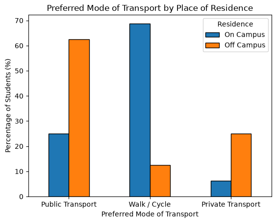

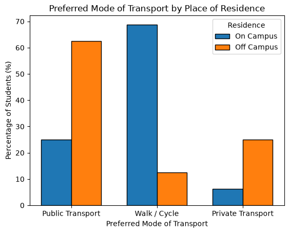

```python
# Method 1: Using a proportion table with pandas .plot()
# Build a DataFrame from the raw counts, with transport modes as the row index
# and residence type as columns.
modes = ["Public Transport", "Walk / Cycle", "Private Transport"]
df = pd.DataFrame({"On Campus": on_campus, "Off Campus": off_campus}, index=modes)
# Convert raw counts into percentages within each residence group.
df_proptab = df.div(df.sum(axis=0), axis=1) * 100
# Plot directly from the DataFrame — pandas automatically creates a grouped bar plot,
# positioning "On Campus" and "Off Campus" bars side by side for each mode,
# using the index as x-axis labels.
df_proptab.plot(kind="bar",edgecolor="black")
plt.xlabel("Preferred Mode of Transport")
plt.ylabel("Percentage of Students (%)")
plt.title("Preferred Mode of Transport by Place of Residence")
plt.legend(title="Residence")
plt.xticks(rotation=0)
plt.show()

# Method 2: Using plt.bar() with manual bar positioning
# Create numeric base positions for each mode (0, 1, 2, ...), since
# plt.bar() needs numeric x-coordinates to offset bars — it can't
# automatically group by a text label the way pandas .plot() does.
x = np.arange(len(modes))
width = 0.35
# Plot each residence group as its own set of bars, shifted left/right
# by half the bar width so the two bars for each mode sit side by side
# without overlapping.
plt.bar(x - width / 2, on_campus_pct, width, label="On Campus",edgecolor="black")
plt.bar(x + width / 2, off_campus_pct, width, label="Off Campus",edgecolor="black")
plt.xlabel("Preferred Mode of Transport")
plt.ylabel("Percentage of Students (%)")
plt.title("Preferred Mode of Transport by Place of Residence")
# Replace the numeric x-axis positions (0, 1, 2) with the actual mode names
plt.xticks(x, modes)
plt.legend(title="Residence")

plt.show()
```

Percentages are more appropriate than raw counts here because the two residence groups have different sample sizes. Using percentages allows us to compare the distributions fairly across the two groups.

(c) Based on your calculations and graphical display, does there appear to be an association between **place of residence** and **preferred mode of transport**? Briefly explain.

Yes, there appears to be an association between place of residence and preferred mode of transport.  
Students living on campus are much more likely to walk or cycle (68.75%), whereas students living off campus are much more likely to use public transport (62.5%). Private transport is also more common among students living off campus (25.0%) than among those living on campus (6.25%).  
Since the distributions of preferred mode of transport differ noticeably between the two residence groups, the two variables appear to be associated.

(d) Calculate the difference in proportions and the relative risk of preferring public transport, comparing on-campus and off-campus students. What do these values suggest about the strength of the association?

For students living **on campus**,

$$ \hat{p}_{\text{on}} = \frac{20}{80} = 0.25 $$

For students living **off campus**,

$$ \hat{p}_{\text{off}} = \frac{75}{120} = 0.625 $$

The **difference in proportions** is

$$ \hat{p}_{\text{off}} - \hat{p}_{\text{on}} = 0.625 - 0.25 = 0.375 $$

Thus, the proportion of students who prefer public transport is **37.5 percentage points higher** among students living off campus.

The **relative risk** is

$$ \frac{\hat{p}_{\text{off}}}{\hat{p}_{\text{on}}} = \frac{0.625}{0.25} = 2.5 $$

Thus, students living off campus are **2.5 times as likely** to prefer public transport as students living on campus.

Both measures indicate a substantial difference between the two groups, suggesting an association between residence and preference for public transport.

The difference in proportions measures the **absolute difference** between the two groups, while the relative risk measures the difference on a **relative scale**.

A relative risk of 1 would indicate equal proportions in the two groups. Here, the relative risk is 2.5, which indicates a substantial difference in the likelihood of preferring public transport between off-campus and on-campus students.

### Question 3

A study investigates whether students' exercise frequency is associated with the number of hours they sleep per night. Students are classified into two groups: Regular Exercise and Little/No Exercise.

The distributions of nightly sleep duration for the two groups are shown in Figure 1.

[figure not shown]

*Figure 1*

(a) Compare the distributions of nightly sleep duration between the two exercise groups in terms of centre and variability.

The **regular exercise** group has a higher centre, with a median nightly sleep duration of about **7.6 hours**, compared with about **6.3 hours** for the little/no exercise group.

The **little/no exercise** group shows greater variability in sleep duration, with a wider overall spread than the regular exercise group.

For **centre**, we can compare the medians shown by the lines inside the boxes. For variability, we can compare the IQR and the overall spread of the two distributions.

Overall, students who exercise regularly tend to sleep longer, while sleep duration among students who exercise little or not at all is more variable.

(b) Are there any outliers shown in the boxplots? If so, identify the group in which they occur and describe them.

Yes. There is a **high outlier** in the little/no exercise group, corresponding to a nightly sleep duration of approximately **9.2 hours**.

There are no apparent outliers in the regular exercise group.

In a boxplot, observations plotted individually beyond the whiskers are identified as potential outliers.

(c) Based on Figure 1, does there appear to be an association between exercise frequency and nightly sleep duration? Briefly explain.

Yes, there appears to be an **association between exercise frequency and nightly sleep duration**.

Students who exercise regularly tend to have longer nightly sleep durations than students who exercise little or not at all, as shown by the higher centre of the regular exercise group's distribution.

An association is suggested because the distribution of nightly sleep duration differs between the two exercise groups, particularly in terms of centre.

This indicates an **association**, but does not imply that regular exercise **causes** longer sleep duration.

### Question 4

A researcher investigates the relationship between students' **weekly study hours** and their **final examination scores**. The data for 30 students are shown in Figure 2.

[figure not shown]

*Figure 2*

(a) Describe the association between weekly study hours and final examination scores shown in Figure 2.

There is a **strong, positive, approximately linear association** between weekly study hours and final examination scores.

In general, students who study more hours per week tend to have higher final examination scores. Most of the points lie fairly close to an upward linear trend.

When describing the association between two quantitative variables, consider the **direction**, **form**, and **strength** of the relationship.

Here, the direction is **positive** because examination scores generally increase as study hours increase. The relationship is **approximately linear**, and it appears **strong** because most points lie fairly close to the overall linear pattern.

(b) Identify and describe any observations that deviate noticeably from the overall pattern.

One observation deviates noticeably from the overall pattern: a student who studies approximately **10.5 hours per week** has a final examination score of only about **58**.

This point lies well below the overall positive linear pattern and may be considered an **outlier**.

An outlier is an observation that stands out noticeably from the overall pattern of the data.

Although studying about 10.5 hours per week would generally be associated with a much higher examination score based on the overall pattern, this student scored only about 58.

### Question 5

The dataset `Animals.csv` contains information on the **gestation period** and **average longevity** of 21 different animals.

Use Python to answer the following questions.

(a) Calculate the **correlation coefficient** between gestation period and longevity. Interpret its **sign and magnitude** in the context of the data.

```python
animals = pd.read_csv("../data/Animals.csv")

animals.head()
```

|  | animal | gestation | longevity |
| --- | --- | --- | --- |
| 0 | Ass | 365 | 19 |
| 1 | Bear | 220 | 22 |
| 2 | Cat | 61 | 11 |
| 3 | Chicken | 22 | 7 |
| 4 | Cow | 280 | 11 |

```python
correlation = animals["gestation"].corr(animals["longevity"])

print(f"Correlation coefficient: {correlation:.3f}")
```

```
Correlation coefficient: 0.856
```

The correlation coefficient between gestation period and longevity is approximately $r = \mathbf{0.856}$.

The correlation is **positive**, indicating that animals with longer gestation periods tend to have longer average lifespans.

The magnitude of the correlation indicates a **strong positive linear association** between gestation period and longevity.

The **sign** of the correlation coefficient indicates the **direction** of the linear association, while its **magnitude** indicates the **strength** of the linear association.

The observed relationship may be reasonable in real life, but we should be careful not to interpret the association as causation. A positive correlation does not mean that a longer gestation period **causes** an animal to live longer.

(b) Construct and describe a scatter plot of longevity against gestation period and identify any observation(s) that deviates noticeably from the overall pattern. Then, use the IQR rule to check whether the observation(s) is/are an outlier for both variables.

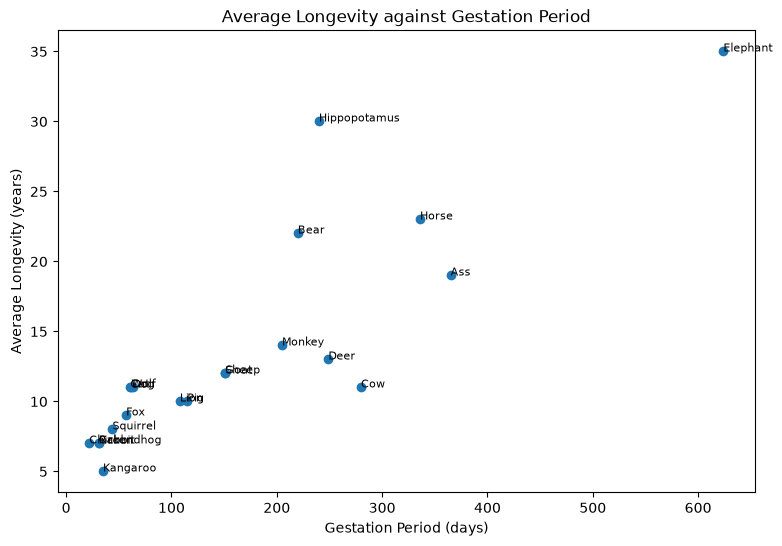

```python
plt.figure(figsize=(9, 6))

plt.scatter(animals["gestation"], animals["longevity"])

for _, row in animals.iterrows():
    plt.annotate(row["animal"], (row["gestation"], row["longevity"]), fontsize=8)

plt.xlabel("Gestation Period (days)")
plt.ylabel("Average Longevity (years)")
plt.title("Average Longevity against Gestation Period")

plt.show()
```

```python
Q1 = animals["longevity"].quantile(0.25)
Q3 = animals["longevity"].quantile(0.75)

IQR = Q3 - Q1

lower_bound_long = Q1 - 1.5 * IQR
upper_bound_long = Q3 + 1.5 * IQR

print("Q1:", Q1)
print("Q3:", Q3)
print("IQR:", IQR)
print("Lower bound:", lower_bound_long)
print("Upper bound:", upper_bound_long)

# Filter the DataFrame down to only the rows where "longevity" falls
# outside the [lower_bound, upper_bound] range — i.e., the outliers
# according to the 1.5 x IQR rule.
# Then select just the "animal", "gestation", and "longevity" columns,
# so the output identifies WHICH animals are outliers and their values,
# rather than showing every column in the DataFrame.
longevity_outlier = animals[
    (animals["longevity"] < lower_bound_long) | (animals["longevity"] > upper_bound_long)
][["animal", "gestation", "longevity"]]
print(longevity_outlier)
```

```
Q1: 9.0
Q3: 14.0
IQR: 5.0
Lower bound: 1.5
Upper bound: 21.5
          animal  gestation  longevity
1           Bear        220         22
7       Elephant        624         35
11  Hippopotamus        240         30
12         Horse        336         23
```

```python
Q1 = animals["gestation"].quantile(0.25)
Q3 = animals["gestation"].quantile(0.75)

IQR = Q3 - Q1

lower_bound_gest = Q1 - 1.5 * IQR
upper_bound_gest = Q3 + 1.5 * IQR

print("Q1:", Q1)
print("Q3:", Q3)
print("IQR:", IQR)
print("Lower bound:", lower_bound_gest)
print("Upper bound:", upper_bound_gest)

# Filter the DataFrame down to only the rows where "gestation" falls
# outside the [lower_bound, upper_bound] range — i.e., the outliers
# according to the 1.5 x IQR rule.
# Then select just the "animal", "gestation", and "longevity" columns,
# so the output identifies WHICH animals are outliers and their values,
# rather than showing every column in the DataFrame.
gestation_outlier = animals[
    (animals["gestation"] < lower_bound_gest) |
    (animals["gestation"] > upper_bound_gest)
][["animal", "gestation", "longevity"]]
print(gestation_outlier)
```

```
Q1: 57.0
Q3: 240.0
IQR: 183.0
Lower bound: -217.5
Upper bound: 514.5
     animal  gestation  longevity
7  Elephant        624         35
```

```python
common_outliers = longevity_outlier[longevity_outlier["animal"].isin(gestation_outlier["animal"])]
print(common_outliers)
```

```
     animal  gestation  longevity
7  Elephant        624         35
```

The scatter plot shows an overall **positive association** between gestation period and average longevity.

The **Elephant** deviates most noticeably from the overall pattern. It has a gestation period of **624 days** and an average longevity of **35 years**, both of which are considerably higher than those of the other animals.

Using the **IQR rule** provides further evidence that the Elephant has unusually large values. It is identified as an outlier for both **gestation period** and **average longevity**.

The scatter plot allows us to visually identify observations that stand out from the overall pattern, while the **IQR rule** provides a numerical method for identifying outliers in each quantitative variable.

(c) Remove the observation identified in part (b) and recalculate the correlation coefficient. Compare the correlation coefficients before and after removing the observation.

```python
# Remove the Elephant
animals_no_elephant = animals[animals["animal"] != "Elephant"]

# Recalculate the correlation coefficient
correlation_no_elephant = animals_no_elephant["gestation"].corr(animals_no_elephant["longevity"])

print(f"Correlation before removing Elephant: {correlation:.3f}")
print(f"Correlation after removing Elephant: {correlation_no_elephant:.3f}")
```

```
Correlation before removing Elephant: 0.856
Correlation after removing Elephant: 0.752
```

The correlation coefficient decreases after the Elephant is removed, although the association remains positive and relatively strong.

This suggests that the Elephant has a noticeable influence on the correlation coefficient and strengthens the apparent positive linear association between gestation period and average longevity.

This illustrates why the correlation coefficient should not be interpreted in isolation. An observation that is far from the rest of the data can have a substantial influence on the value of $\mathbf{r}$.

(d) Another dataset has a correlation coefficient close to 0, but its scatter plot is shown in Figure 3. Does a correlation coefficient close to 0 necessarily imply that there is no association between two variables? Explain using Figure 3.

[figure not shown]

*Figure 3*

No. A correlation coefficient close to 0 does **not necessarily imply that there is no association** between two variables.

Figure 3 shows a clear **non-linear association** between $X$ and $Y$. As $X$ increases from negative values towards 0, $Y$ decreases; as $X$ increases beyond 0, $Y$ increases.

Therefore, although the correlation coefficient is close to 0, there is still a strong relationship between the two variables. The correlation coefficient is close to 0 because it measures the strength and direction of a **linear relationship**, and the relationship shown here is non-linear.

The correlation coefficient measures the **strength and direction of a linear relationship**. It does not measure all possible forms of association between two quantitative variables.

Therefore, a correlation coefficient close to 0 indicates little or no **linear association**, but a strong **non-linear association** may still exist. This is why a scatter plot should always be examined together with the correlation coefficient.